# Using reticulate’s Python Engine with knitr

Python variables live across chunk boundaries.

```python
x = 1
y = 2
```

```python
print(x)
```

```
## 1
```

```python
print(y)
```

```
## 2
```

Plots generated by `matplotlib` are properly displayed.

```python
import matplotlib.pyplot as plt

plt.plot([1, 2, 3, 4])
plt.show()
```

[figure not shown]

```python
plt.plot([1, 2, 3, 4])
plt.show()
```

[figure not shown]

Python can access objects available in the R environment.

```r
x <- 1:5
y <- 6:10
```

```python
print (r.x)
```

```
## [1, 2, 3, 4, 5]
```

```python
print (r['y'])
```

```
## [6, 7, 8, 9, 10]
```

```python
r.hello = "World"
r['answer'] = 42
```

```r
print(hello)
```

```
## [1] "World"
```

```r
print(answer)
```

```
## [1] 42
```

Arbitrary R code can be evaluated from Python.

```python
mpg = r["mtcars$mpg[1:5]"]
print(mpg)
```

```
## [21.0, 21.0, 22.8, 21.4, 18.7]
```

- #126: Ensure single-line Python chunks that produce no output still have source code emitted.

```python
y = "a,b,c".split(",")
```

```python
print(y)
```

```
## ['a', 'b', 'c']
```

- #130: The `echo` chunk option is respected (for `TRUE` and `FALSE` values). Output, but not source, should show in the following output.

```
## Chunk with echo = FALSE
```

- #130: The `results` chunk option is respected for Python outputs. Source, but not output, should show in the following output.

```python
print ("Chunk with results = 'hide'")
```

- #130: The `include` chunk option is respected for Python outputs. No chunk output should appear following this bullet.
- #130: The `eval` chunk option is respected for Python outputs.

```python
# We have set 'eval = FALSE' here
r["abc"] = 1
```

```r
exists("abc", envir = globalenv())
```

```
## [1] FALSE
```

Respect the `error=TRUE` chunk option – allow execution even after a Python error occurs.

```python
raise RuntimeError("oops!")
```

```
## Error in py_call_impl(callable, dots$args, dots$keywords): RuntimeError: oops!
##
## Detailed traceback:
##   File "<string>", line 1, in <module>
```

```python
print("This line is still reached.")
```

```
## This line is still reached.
```

Ensure that lines with multiple statements are only run once.

```python
print("abc"); print("123")
```

```
## abc
## 123
```

Ensure that syntax errors do not block document generation when `eval = FALSE`.

```python
here be syntax errors
```

Output from bare statements should also be printed.

```python
"Hello, world!"
```

```
## 'Hello, world!'
```

```python
[x for x in range(10)]
```

```
## [0, 1, 2, 3, 4, 5, 6, 7, 8, 9]
```

Expressions that generate plots should be shown.

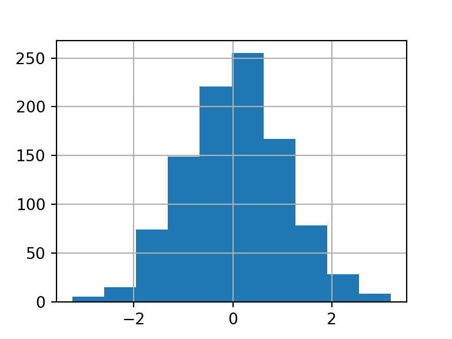

```python
import numpy as np, pandas as pd
a = np.random.normal(size=1000)
pd.Series(a).hist()
```